# 2<sup>nd</sup> exercise: Data summary and regression analysis basics

The exercise consist 5 parts, which are separated in own sections (*below*). Data for the exercise was read from http://www.helsinki.fi/~kvehkala/JYTmooc/JYTOPKYS3-data.txt and it was processed (data wrangling) using a R script ([create_learning2014.R](https://github.com/Puolimatkassa/IODS-project/tree/master/scripts)). Data is stored into /data/learning2014.csv file. I won’t go into details about the data wrangling, so look at the file if interested.

Scripts can be found from my /scripts folder in IODS-project’s github repository.

### 1<sup>st</sup> part

First things first, so let’s read the data

```r
learning_data <- read.table("data/learning2014.csv",sep=",",header=T)
```

Data in this exercise is sample of bigger student questionnaire. It has 7 variables and 166 observations and the structure is following:

```r
str(learning_data)
```

```
## 'data.frame':    166 obs. of  7 variables:
##  $ gender  : chr  "F" "M" "F" "M" ...
##  $ Age     : int  53 55 49 53 49 38 50 37 37 42 ...
##  $ Attitude: int  37 31 25 35 37 38 35 29 38 21 ...
##  $ deep    : num  3.58 2.92 3.5 3.5 3.67 ...
##  $ stra    : num  3.38 2.75 3.62 3.12 3.62 ...
##  $ surf    : num  2.58 3.17 2.25 2.25 2.83 ...
##  $ Points  : int  25 12 24 10 22 21 21 31 24 26 ...
```

Questionnaire is about different kind of studying orientations. Orientation approaches were deep, surface (surf) and strategic (stra) approached orientations. In addition, gender, age, points and attitude were recorded from the students.

### 2<sup>nd</sup> part

In table (*below*), is summary of data. One third of students were male. The median age was 22, but having a some old students too.

| **Characteristic** | **N = 166**<sup>1</sup> |
| --- | --- |
| gender |  |
| F | 110 (66%) |
| M | 56 (34%) |
| Age | 22 (21, 27) |
| Attitude | 32 (26, 37) |
| deep | 3.67 (3.33, 4.08) |
| stra | 3.19 (2.62, 3.62) |
| surf | 2.83 (2.42, 3.17) |
| Points | 23 (19, 28) |

<sup>*1*</sup> n (%); Median (IQR)

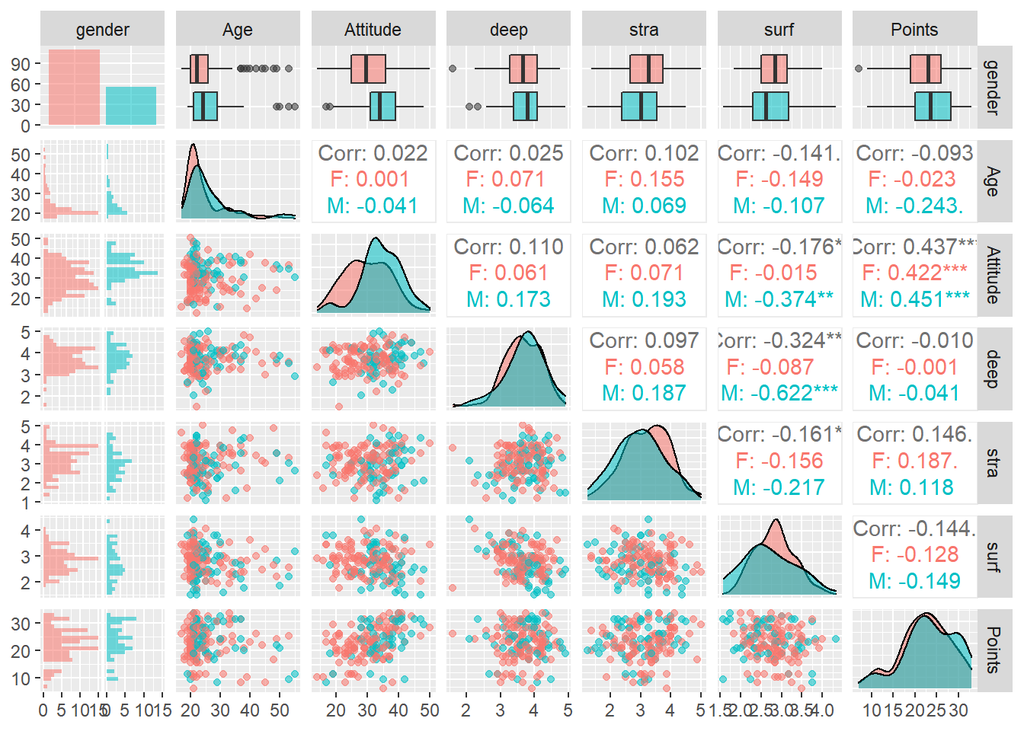

Summary of learning_data

### 3<sup>rd</sup> and 4<sup>th</sup> part

The rest of the analysis is done for whole dataset (female and male compined).

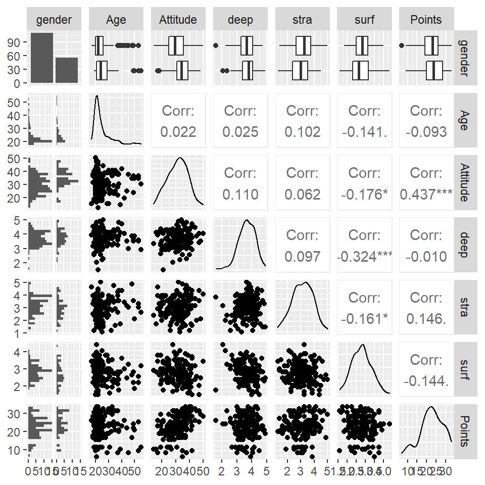

Summary of learning_data

Let assume that the total points gained can be ‘explained’ using three variables: attitude, age and strategic approach. Let’s assume that total points is linear combinations of those variables and errors are normally distributed, not correlated and have constant variance, $\sigma^2$. First, let’s plot each variable separately against the points.

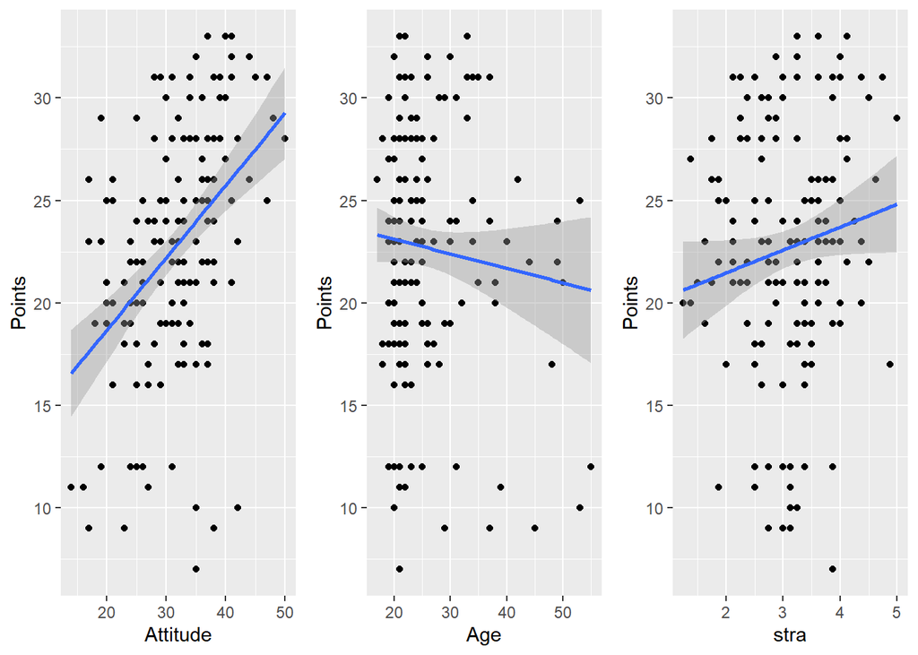

Next, let’s do a linear regression analysis to the data and see what it tells us.

```r
my_model1 <- lm(Points ~ Attitude + Age + stra, data = learning_data)
summary(my_model1)
```

```
##
## Call:
## lm(formula = Points ~ Attitude + Age + stra, data = learning_data)
##
## Residuals:
##      Min       1Q   Median       3Q      Max
## -18.1149  -3.2003   0.3303   3.4129  10.7599
##
## Coefficients:
##             Estimate Std. Error t value Pr(>|t|)
## (Intercept) 10.89543    2.64834   4.114 6.17e-05 ***
## Attitude     0.34808    0.05622   6.191 4.72e-09 ***
## Age         -0.08822    0.05302  -1.664   0.0981 .
## stra         1.00371    0.53434   1.878   0.0621 .
## ---
## Signif. codes:  0 '***' 0.001 '**' 0.01 '*' 0.05 '.' 0.1 ' ' 1
##
## Residual standard error: 5.26 on 162 degrees of freedom
## Multiple R-squared:  0.2182, Adjusted R-squared:  0.2037
## F-statistic: 15.07 on 3 and 162 DF,  p-value: 1.07e-08
```

It seems that student’s attitude is the best variable to forecasts student’s total points after one year. Interestingly, age seems to correlate negatively with the total points. Let’s remove age from our model and run the linear regression analysis again.

```r
my_model2 <- lm(Points ~ Attitude + stra, data = learning_data)
summary(my_model2)
```

```
##
## Call:
## lm(formula = Points ~ Attitude + stra, data = learning_data)
##
## Residuals:
##      Min       1Q   Median       3Q      Max
## -17.6436  -3.3113   0.5575   3.7928  10.9295
##
## Coefficients:
##             Estimate Std. Error t value Pr(>|t|)
## (Intercept)  8.97290    2.39591   3.745  0.00025 ***
## Attitude     0.34658    0.05652   6.132 6.31e-09 ***
## stra         0.91365    0.53447   1.709  0.08927 .
## ---
## Signif. codes:  0 '***' 0.001 '**' 0.01 '*' 0.05 '.' 0.1 ' ' 1
##
## Residual standard error: 5.289 on 163 degrees of freedom
## Multiple R-squared:  0.2048, Adjusted R-squared:  0.1951
## F-statistic: 20.99 on 2 and 163 DF,  p-value: 7.734e-09
```

Nothing special happens?! I’m getting bit tired and please let me know what I should have learned about this :D

### 5<sup>th</sup> part

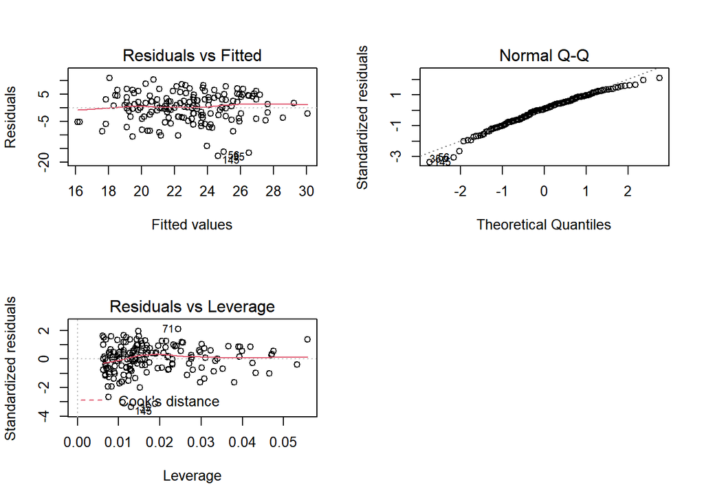

```r
par(mfrow=c(2,2))
plot(my_model2, which = c(1,2,5))
```

*interpretation*:

- From the Q-Q plot supports assumption that the errors of the model are normally distributed (or it was reasonable).
- Residual plot does not show any clear patterns, so I probably can assume that the errors have constant variance (more or less random scatter plot).
- It seems that no observations in our dataset that has high leverage on our fit.